# Statistical Analysis

## Section 1: Statistics Concepts

### 1. Normal distribution

$$\begin{aligned}
\text{PDF} &= \dfrac{1}{\sigma\sqrt{2\pi} } \ \text{exp}\bigg( -\dfrac{(x_i-\mu)^2}{2\sigma^2}\bigg) \\
\underbrace{\text{Log Likelihood}}_{\text{ for } n \text{ independent } N(\mu, 1)} &= \dfrac{1}{2} \sum_{i=1}^n (x_i - \mu)^2 - n \log(\sqrt{2 \pi})\\
\sigma^2 &= \dfrac{1}{n - 1} \sum_{i=1}^n (x_i - \mu)^2 \\
\text{SE} &= \dfrac{\sigma}{\sqrt{n}}
\end{aligned}$$

#### R functions

- dnorm : Density or height of prob distribution
- pnorm : Cumulative distribution (area) probability
- qnorm : inverse of pnorm give quantile, give prob, returns z score
- rnorm : random number from normal distribution

popultion property

```r
u = 10000 # mean
sigma = 1000 # standard deviation
# If you select 10 humans at random, what is the probablity that the average is greater than 10300 ?
N = 10
se = sigma / sqrt(N)
z= (10300 - u) / se
prob= 1 - pnorm(z)
prob
```

```
[1] 0.1713909
```

```r
# What is the probablity that the average number of tastebds they have is between 9500 and 10500
z1 = (9500 - u)/se
z2= (10500 - u)/se
prob2= pnorm(z2) - pnorm(z1)
prob2
```

```
[1] 0.8861537
```

### 2. Z Statistics

```r
# Z value
z1= qnorm(p = 0.95, mean = 0, lower.tail = T)
z2= qnorm(p = 0.95, mean = 0, lower.tail = F)
z3= qnorm(p = 0.975, mean = 0, lower.tail = T)
sprintf('z1 = %f z2 = %f z3 = %f', z1, z2, z3)
```

```
[1] "z1 = 1.644854 z2 = -1.644854 z3 = 1.959964"
```

```r
sprintf('p1 = %f p1 = %f, p3 = %f', pnorm(z1), pnorm(z2), pnorm(z2))
```

```
[1] "p1 = 0.950000 p1 = 0.050000, p3 = 0.050000"
```

### 3. Standard Error: SE

The following code shows that the larger the number of samples draw from a population, the smaller SE of sample mean.

```r
# simple line of code
x = 10
my.f = function(N){
  # create a random normal distribution
  z = rnorm(N)
  # Find mean
  zbar = mean(z)
  return(zbar)
}
result = replicate(n = 10000, expr = my.f(10))
result2 = replicate(n = 10000, expr = my.f(20))
result3 = replicate(n = 10000, expr = my.f(50))
plot(density(result))
lines(density(result2) , col='red')
```

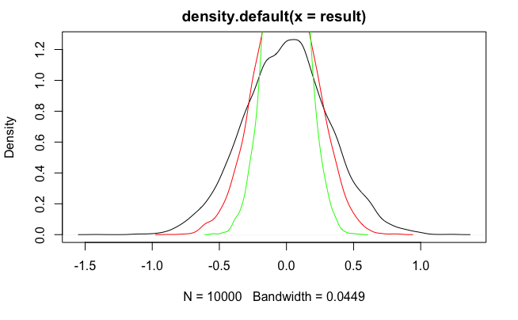

```r
lines(density(result3) , col='green')
```

### 4. **Center Limit Theorem**

**Definition**: when independent random variables are added, their properly normalized sum tends toward a normal distribution even if the original variables themselves are not normally distributed.

Sample distribution of variables, we use sample with replacement because population size is small and every draw has the same distribution and can draw many number of times

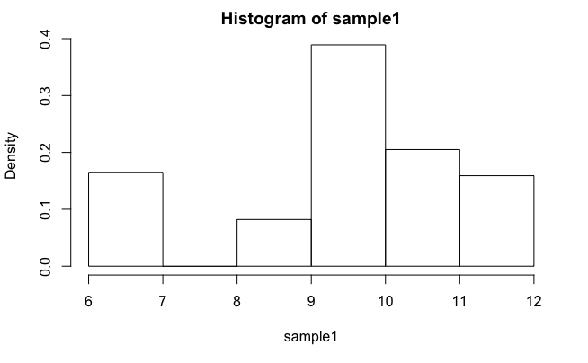

```r
# Please note the sample are the shoe sizes
shoe.pop = c(12, 11, 10, 11.5, 11, 11, 8.5,7, 6.5, 9.5, 10, 9.5, 9.5)
N = 1000 # Sample size
sample1 = sample(shoe.pop, size=N, replace=TRUE)
mean.sample <- mean(sample1)
sd.sample <- sd(sample1)
hist(sample1, breaks=5, probability = TRUE)
```

Sample size N determine the SE sigma/sqrt(N), the larger the N, the smaller the SD of the mean, the tight the curve. As N increases, sample mean distribution become close to normal distribution

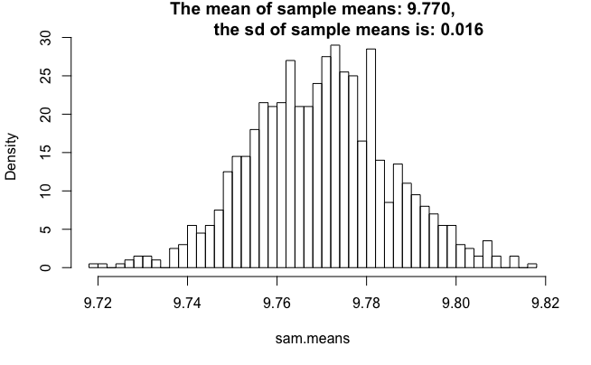

```r
mysamplemean <- function(N) {
    sam1 = sample(shoe.pop, size=N, replace=TRUE)
    sam.mean = mean(sam1)
    return(sam.mean)
}
samplesize <- 10000
sam.means <- replicate(n=1000, mysamplemean(samplesize))
sam.means.mean = mean(sam.means)
sam.means.sd  = sd(sam.means)
prs <- sprintf("The mean of sample means: %2.3f,
               the sd of sample means is: %2.3f", sam.means.mean, sam.means.sd)
hist(sam.means, breaks = 50, probability = TRUE, main = prs)
```

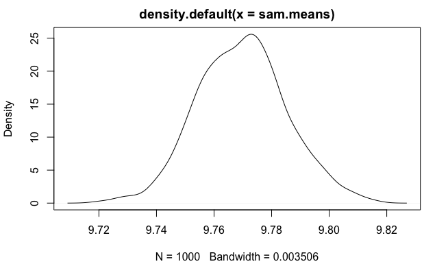

```r
plot(density(sam.means))
```

**Why central Limint Theorm is Significant? The frequncy distribution of sample means of any underlying distribution with very large sample size is a normal distribution which is a nice assumption. When sample size is large, we use apply property of normal distribution**

### 5. Confidence Interval

**Definition**: If we were to draw 100 samples from same population, approximately 95 of them would contain the parameter. In other words, We sample from a distribution and calculate the mean, there are 95% probability the mean will fall into the confidence interval

It measure of variability due to sampling error. Different samples drawn from that same population would in general have different values of the sample mean, so there is a distribution of sampled means.

Use normal distribution to approximate the distribution of error about a binomially-distributed observation. The Central Limit Theorem applies poorly to this distribution with a sample size less than 30 or where the proportion is close to 0 or 1.

$$\text{CI} = p \pm 1.96 \times \underbrace{\text{SE for percent}}_{\text{w/ replacement}}$$

```r
confint = function(SampleSize) {
    x = runif(SampleSize)
    pop.sd = 0.2886895 # population standard deviation
    x.bar = mean(x) # Sample mean
    se = pop.sd/sqrt(SampleSize) # SE
    upper = x.bar + 1.96*se # upper = mean + z (alpha/2) * SE
    lower = x.bar - 1.96*se # lower = mean - z (alpha/2) * SE
    contained = (lower < 0.5 ) & (0.5 < upper)
    return(contained)
}
res = replicate(1e3 , confint(SampleSize = 1000) )
print(mean(res))
```

```
[1] 0.953
```

## Section 2. Statistical Testing

### 1. Hypothesis Testing Definition

**Definition**: Hypothesis statements contain two or more variables that are **measurable** that specify how the variables are related

- H0: null hypothesis
- Ha: alternative hypothesis
- A test is rule of rejecting H0 based on the observed data and risk-level (Reject H0 if …)
  - if p_value < 0.05
  - if |Z| > Z_alpha for 2 tails, Z < -Z_alpha, Z > Z_alpha 1 tail
- 2 Actions: Reject H0 or do not reject H0

|  | H0 True | Ha True |
| --- | --- | --- |
| Reject H0 | Type 1 Err (FP) |  |
| Not Reject H0 |  | Type 2 err (FN) |

#### Example 1

You take a random sample of 100 Berkeley students to find out if their ground beef consumption is any different than the nation at large. The mean among sample is 2.45 pounds per month. What is the p-value corresponding to the null hypothesis that Berkeley students eat the same amount, on the average compare to the nation at large? what is an appropriate alternative hypothesis?

- H0: u_berkeley = u_nation
- Ha: u_berkeley != u_nation

```r
u_berkeley = 2.45 # sample mean
u = 2 # population mean
sd = 2 # population sd
N = 100 # sample size
Z_berkeley = (u_berkeley - u) / (sd/sqrt(N))
alpha = 0.05 # alpha/2 = 0.025
alpha_2_tail = alpha/2
p_value = 2 * (1 - pnorm(Z_berkeley))
p_value
```

```
[1] 0.02444895
```

```r
p_value < alpha_2_tail
```

```
[1] TRUE
```

p_value is < 0.025 which is statistically significant, we can reject the H0 that berkeley student’s ground beef consumption is the same as average consumption of the nation

#### Hypothesis Test function

A function that takes a sample data, mean of the null hypothesis, population standard deviation a boolean variable for 1 or 2 tailed test a boolean variable for left or right tail, return P-value for this test, and use 5% critical value $\alpha$

```r
hp_test = function(sample_data, mean_null, sd_p, two_tailed=TRUE, left_tail=NULL) {
    alpha <- 0.05 # Use 5% critical value
    N <- length(sample_data) # Calculate sample size
    sample_mean <- mean(sample_data) # Calculate sample mean from the sample data
    se <- sd_p/sqrt(N) # calculate SE
    z_score <- (sample_mean - mean_null) / se # Calculate Z-score
    # Hypothesis testing
    # two_tailed is true: 2 tailed test, false: 1 tailed test
    # left_tail is true: left, False: right
    if (two_tailed) {
        p_value <- 2 * (1- pnorm(abs(z_score)))
        reject <- p_value < alpha
    } else {
        if (left_tail) {
            p_value <- pnorm(z_score)
            reject <- p_value < alpha
        } else {
            p_value <- 1 - pnorm(z_score)
            reject <- p_value < alpha
        }
    }
    result <- list(p.value = p_value, reject.null = reject)
    return(result)
}
display_result = function(r) {
    if (r$reject.null) {
        paste("We reject the null hypthesis. The P-value of the test is ", r$p.value)
    } else {
        paste("We do not reject the null hypthesis. The P-value of the test is ", r$p.value)
    }
}
```

### 2. Test Assumptions

#### Assumption 1: Normality

- **Shapiro-Wilk**: Test whether a series normally distributed. This is to test assumption data. The **Null** is that the underlying data is normally distributed. We can also use qq-norm plot
- Transform data/Feature transform

```r
library(ggplot2)
library(car)
library(psych)
# load the countries dataset, including
# corruption and internet growth variables
load("./data/Countries2.Rdata")
summary(Countries)
```

```
   Country          infant.mortality      gdp        fertility_rate  contraception
 Length:190         Min.   :  3.00   Min.   :   36   Min.   :1.190   Min.   : 2.00
 Class :character   1st Qu.: 13.00   1st Qu.:  435   1st Qu.:1.855   1st Qu.:19.75
 Mode  :character   Median : 35.00   Median : 1570   Median :3.070   Median :46.00
                    Mean   : 46.48   Mean   : 6195   Mean   :3.542   Mean   :41.49
                    3rd Qu.: 72.50   3rd Qu.: 6232   3rd Qu.:5.025   3rd Qu.:61.25
                    Max.   :154.00   Max.   :42416   Max.   :7.600   Max.   :83.00
                    NA's   :47       NA's   :45      NA's   :47      NA's   :78
      region    Country_Code internet_users_2010 internet_users_2011 Corruption_Rank
 Africa  :42   AFG    :  1   Min.   : 0.25       Min.   : 0.98       Min.   :  1.00
 Americas:26   AGO    :  1   1st Qu.:10.00       1st Qu.:11.67       1st Qu.: 44.50
 Asia    :28   ALB    :  1   Median :27.67       Median :32.00       Median : 88.00
 Europe  :38   AND    :  1   Mean   :33.61       Mean   :37.50       Mean   : 87.17
 Oceania :14   ARG    :  1   3rd Qu.:53.00       3rd Qu.:59.50       3rd Qu.:130.75
 NA's    :42   (Other):143   Max.   :95.00       Max.   :95.02       Max.   :174.00
               NA's   : 42   NA's   :45          NA's   :50          NA's   :14
      cpi        internet_growth      high_cpi         high_gdp
 Min.   : 8.00   Min.   :-0.12500   Length:190         High:72
 1st Qu.:28.75   1st Qu.: 0.05765   Class :character   Low :73
 Median :37.00   Median : 0.11321   Mode  :character   NA's:45
 Mean   :43.27   Mean   : 0.21683
 3rd Qu.:56.25   3rd Qu.: 0.24764
 Max.   :90.00   Max.   : 2.92000
 NA's   :14      NA's   :51
```

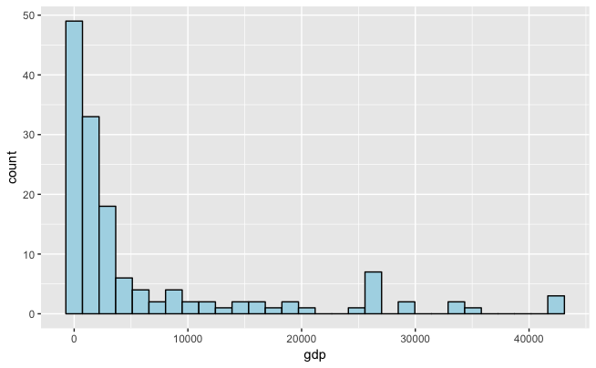

```r
# use a histogram to see if the distribution of gdp looks normal
graph1 = ggplot(Countries, aes(gdp))
graph1 + geom_histogram(color='black', fill='light blue')
```

```r
# check normality using a qqplot
qqplot = qplot(sample = Countries$gdp, stat="qq")
```

```
`stat` is deprecated
```

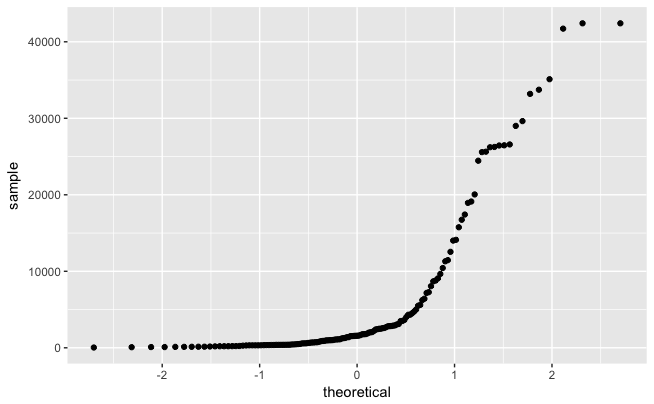

```r
qqplot
```

```r
# Finally, use a Shapiro-Wilk test to see if normality is a plausible hypothesis
shapiro.test(Countries$gdp)
```

```
    Shapiro-Wilk normality test

data:  Countries$gdp
W = 0.64501, p-value < 2.2e-16
```

Shapiro-Wilk show p-value < 0.05 which is statistical significant, we can reject the null hypothese that the data is normally distributed

To transform to using log (this is common on econometric data)

```r
# Next, let's do the same thing with the log of gdp
# This is a very common transformation in econometrics
Countries$loggdp = log10(Countries$gdp)

# Begin with the Shapiro-Wilk test
shapiro.test(Countries$loggdp)

# But look at the shape of the qqplot
qqnorm(Countries$loggdp)

# use a histogram to see if the distribution of loggdp looks normal
graph1 = ggplot(Countries, aes(x = loggdp))
graph1 + geom_histogram(color = 'black', fill = 'light blue')
```

[output not shown]

#### Assumption 1: Homogenity of variance

- **Levene Test**: Test whether two or more series is satisfy Homogeneity of variance assumption. The **null** is the two series’s variances is homogeneious.

```r
# First, check the means
by(Countries$loggdp, Countries$high_cpi, mean, na.rm = TRUE)

# check if the variances are the same for both groups
by(Countries$loggdp, Countries$high_cpi, var, na.rm = TRUE)

# use a Levene test to see if equal variances is a plausible hypothesis
leveneTest(Countries$loggdp, Countries$high_cpi)
```

[output not shown]

### 3. Test of association

### If numerical => Pearson correlation

### If categorical => Chi-square test

#### Small Example

```r
library(foreign)
insurgency = read.dta("./data/lyall2010.dta")
head(insurgency)
```

|  | ccode | yearbg | strict | lgdpen | treat | dur | startdate | enddate | warid | war | yearend | incumb | insurg | wdl | win | modern | gp | patron | cinc | autoc7 | lenerpc | ltradegdp | elf | heli | mlevel | region | weurope | eeurop | lamerica | … |
| --- | --- | --- | --- | --- | --- | --- | --- | --- | --- | --- | --- | --- | --- | --- | --- | --- | --- | --- | --- | --- | --- | --- | --- | --- | --- | --- | --- | --- | --- | --- |
| 1 | 2 | 1832 | 2 | NA | 1 | 4 | 5/4/1832 | 2/8/1832 | 16 | Blackhawk's War | 1832 | USA | Sauk and Fox Indians | 2 | 1 | 0 | 0 | 0 | 0.0445450 | 0 | -2.7355239 | NA | NA | NA | NA | n. america | 0 | 0 | 0 | … |
| 2 | 2 | 1835 | 2 | NA | 1 | 81 | 28/12/1835 | 14/8/1842 | 18 | Second Seminole War | 1842 | USA | Seminoles | 2 | 1 | 0 | 0 | 0 | 0.0508560 | 0 | -2.4243710 | NA | NA | NA | NA | n. america | 0 | 0 | 0 | … |
| 3 | 2 | 1855 | 2 | NA | 1 | 40 | 1/5/1855 | 23/9/1858 | 37 | Yakima War | 1858 | USA | Yakima | 2 | 1 | 0 | 0 | 0 | 0.0802830 | 0 | -0.6670240 | NA | NA | NA | NA | n. america | 0 | 0 | 0 | … |
| 4 | 2 | 1855 | 2 | NA | 1 | 34 | 7/12/1855 | 8/5/1858 | 38 | Third Seminole War | 1858 | USA | Seminoles | 2 | 1 | 0 | 0 | 0 | 0.0802830 | 0 | -0.6670240 | NA | NA | NA | NA | n. america | 0 | 0 | 0 | … |
| 5 | 2 | 1860 | 2 | NA | 1 | 72 | 1/1/1860 | 31/12/1865 | 45 | Navajo War | 1865 | USA | Navajo | 2 | 1 | 0 | 0 | 0 | 0.1509228 | 0 | -0.5653595 | NA | NA | NA | NA | n. america | 0 | 0 | 0 | … |
| 6 | 2 | 1860 | 2 | NA | 1 | 72 | 1/1/1860 | 31/12/1865 | 46 | Apache War | 1865 | USA | Apaches | 2 | 1 | 0 | 0 | 0 | 0.1509228 | 0 | -0.5653595 | NA | NA | NA | NA | n. america | 0 | 0 | 0 | … |

```r
# variable types
insurgency$dur # Month of war (ratio variable)
```

```
  [1]   4  81  40  34  72  72  24  48   9  12 129  11  49 241 115 121  36   6  30 641
 [21]  30 371 135  17  85   2 176 306  36 240  24  23   1   6  70  58  45   8  30  96
 [41]   3  49   2  31  12  21  48  13  11 120  11   7  24   6   4 134   7   2  39   6
 [61]  12  10  11  31 261   3  51  86   7   6  18  34  93  42 133  52  65  48 359  64
 [81] 369   6  52   7  67  71  99   2  12   4  65  12  96  12  44  30   6 126  11  12
[101]   7  18  18  17  24   5  65  20   1  10  99  24  20  30  31  89  72  80  33  17
[121] 115  50  47  22  11  65   9 190 156 148  66  25  49  49  47  14  12  20   2   1
[141]   2  24  22 141  10  48   6  54  44  52   5 120 144 342  24  11   1  21  21  20
[161]  11  67  33  93  48 105   5  48 162 152  53  29  64  11  11  41 276  72  61   3
[181] 135  36  76   5 109  37 197 310 192 148  95 256 124 178  31 120 109 240 276 209
[201]  80   2  14   2  30  22  42   4  12   5   2  28  36  44 183  60  12  96   1   1
[221]  18  26 187   1   4  62   1  87  12   3 145  20  46  67  29 236 212 204  96 216
[241]  24  12 124  40  34   9  35   5 113  98  45  45 107 252  55 120   9  53  84 288
[261] 542   2  49  29 209  64 165 157  50 124  54 216   3  36 298 349  36 121  84  24
[281] 115  60 131  96 110  15
```

```r
insurgency$wdl # Categorical / Ordinal
```

```
  [1] 2 2 2 2 2 2 2 2 2 2 2 2 2 2 0 0 0 0 1 2 1 1 1 1 1 0 1 1 2 2 2 0 0 2 2 2 2 2 2 2 2
 [42] 0 2 2 2 2 2 2 2 2 2 2 2 2 0 2 2 2 2 1 2 2 2 2 2 2 1 1 0 1 2 0 0 0 2 2 1 0 1 2 2 2
 [83] 0 2 0 0 2 2 2 2 2 2 0 2 2 1 2 2 2 2 2 0 0 2 2 2 2 1 2 0 0 2 2 0 0 0 0 2 2 0 2 2 0
[124] 0 2 2 1 0 0 0 2 2 0 2 0 0 0 0 2 2 2 2 0 2 0 2 0 0 2 2 0 2 2 2 2 2 1 1 0 0 0 1 1 1
[165] 0 2 2 0 0 0 1 0 2 2 2 0 1 0 2 2 0 2 1 0 2 1 0 1 1 2 1 0 0 2 2 2 1 1 1 2 0 2 0 2 2
[206] 2 0 2 1 0 2 0 2 2 1 1 2 1 1 1 2 2 1 2 1 1 2 0 2 2 2 0 0 2 2 2 2 2 2 2 0 0 1 0 0 2
[247] 2 2 2 0 0 0 1 1 2 1 0 1 1 1 1 2 1 1 2 0 1 0 1 0 2 2 2 2 0 1 2 1 2 2 2 2 2 2 0 2
```

```r
insurgency$pol2 # Ordinal variable / Interval variable
```

```
  [1]   9   9   8   8   8   8   8   8  10  10  10  10  10  10  10  10  10  -9  -1  -3
 [21]  -3   3  -4  -8  -5  10  -5   7   6   7  -3   2  -4  -5  -3   6  -2  -2  -2  -2
 [41]  -2   3   3   3   3   3   3   3   3   3   3   3   3   3   7   7   7   7   7   7
 [61]   7   7   7   8   8   8   8   9   8   8  10  10  10  10  10  10  10  10  10  -6
 [81]  -3  -2  10   6  10  -4  -1  -1  -8  -8  -7  -1   6   7   7   7   7  10   7   7
[101] -10   7   7   8   8   9   9   9   9  -9   9  10  10  10  10  10  10  -6  -2  -6
[121]  -2   1   4   4  -6   6  -7  -9  -9  -9   1   1  -9  -9  -9  -9  -9  -9  -9 -10
[141]  -4  -4  -4  -6  -9  -3  -5  -6   0   8   5 -10 -10 -10 -10 -10 -10   4   4   1
[161]   0  -7   4  -6  -5  -6   7   6  -9  -7  -4   4   0  -3  -9   0   0   3   2  -7
[181]  -3  -5  -6  -6  -7  -7   0  -7  -8   4   4   4   4  -9  -8  -7  -7  -7 -10 -10
[201] -10 -10 -10 -10 -10 -10 -10 -10 -10 -10 -10  -1  -1  -6   7  -5  -7  -9  -9  -9
[221] -10  -9   0  -9   9  10  -6   0  -7  -2 -10   0   0  -6  -6  -6  -6  -6  -6  -6
[241]   0  -5  -5  -5  -5  -8  -8   1   1   1   1   1   9   9   9   8   0   8   8  -7
[261]   8   8   5   5  -7  -7  -7  -1  -3  -3   3   5   0  -1  -7  -7  10  10  -1  -1
[281]  -9  -9  -9  -9  -7   1
```

```r
insurgency$occ # Binary
```

```
  [1] 0 0 0 0 0 0 0 0 0 0 0 0 1 1 1 1 1 0 0 0 0 0 0 0 0 0 0 0 0 0 0 0 0 0 0 0 1 1 1 1 1
 [42] 1 1 1 1 1 0 0 1 0 1 0 0 1 1 0 0 0 1 1 0 1 1 1 1 1 0 0 1 1 0 1 1 1 1 1 1 1 0 1 1 1
 [83] 1 1 1 1 1 1 0 1 1 0 0 1 0 1 1 1 1 0 1 0 1 1 1 1 1 1 1 1 1 1 1 1 1 1 1 0 0 1 1 0 1
[124] 1 1 1 1 1 1 1 1 1 1 1 1 1 1 1 1 0 1 1 1 1 1 1 1 0 1 0 0 1 1 0 0 0 1 0 0 1 0 0 0 0
[165] 0 0 0 0 0 0 0 0 0 0 0 0 0 0 0 0 0 0 0 0 0 0 1 0 0 0 0 1 0 0 0 0 0 0 0 0 0 0 0 0 0
[206] 0 0 0 0 0 0 0 0 0 0 0 0 0 0 0 0 0 0 0 1 1 0 0 0 0 0 0 0 0 0 0 0 0 0 0 0 0 0 0 1 0
[247] 0 1 1 1 1 1 0 0 0 0 1 0 0 0 0 0 0 0 0 0 0 0 0 0 0 0 0 0 0 0 0 0 1 0 0 0 1 0 1 0
```

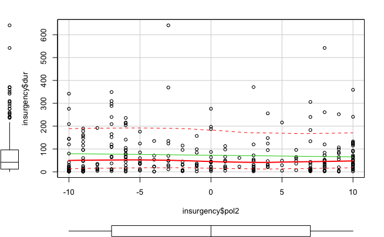

```r
scatterplot(insurgency$pol2, insurgency$dur)
```

```r
cor.test(insurgency$pol2, insurgency$dur)
```

```
    Pearson's product-moment correlation

data:  insurgency$pol2 and insurgency$dur
t = -0.94199, df = 284, p-value = 0.347
alternative hypothesis: true correlation is not equal to 0
95 percent confidence interval:
 -0.17068852  0.06056555
sample estimates:
        cor
-0.05580994
```

```r
cor(insurgency[,c("pol2", "dur")], use = "pairwise.complete.obs")
```

```
            pol2         dur
pol2  1.00000000 -0.05580994
dur  -0.05580994  1.00000000
```

```r
table(insurgency$occ, insurgency$wdl)
```

```
     0  1  2
  0 35 46 93
  1 43  9 60
```

```r
cs = chisq.test(insurgency$occ, insurgency$wdl)
cs
```

```
    Pearson's Chi-squared test

data:  insurgency$occ and insurgency$wdl
X-squared = 20.345, df = 2, p-value = 3.821e-05
```

```r
cs$stdres
```

```
              insurgency$wdl
insurgency$occ           0           1           2
             0 -3.38777319  3.85409426 -0.02038164
             1  3.38777319 -3.85409426  0.02038164
```

```r
cs$expected
```

```
              insurgency$wdl
insurgency$occ        0        1        2
             0 47.45455 33.46154 93.08392
             1 30.54545 21.53846 59.91608
```

#### Create data

```r
# car gives us nice scatterplots
library(car)
# We'll use our Country-by-Country dataset
load("./data/Countries2.Rdata")
summary(Countries)
```

```
   Country          infant.mortality      gdp        fertility_rate  contraception
 Length:190         Min.   :  3.00   Min.   :   36   Min.   :1.190   Min.   : 2.00
 Class :character   1st Qu.: 13.00   1st Qu.:  435   1st Qu.:1.855   1st Qu.:19.75
 Mode  :character   Median : 35.00   Median : 1570   Median :3.070   Median :46.00
                    Mean   : 46.48   Mean   : 6195   Mean   :3.542   Mean   :41.49
                    3rd Qu.: 72.50   3rd Qu.: 6232   3rd Qu.:5.025   3rd Qu.:61.25
                    Max.   :154.00   Max.   :42416   Max.   :7.600   Max.   :83.00
                    NA's   :47       NA's   :45      NA's   :47      NA's   :78
      region    Country_Code internet_users_2010 internet_users_2011 Corruption_Rank
 Africa  :42   AFG    :  1   Min.   : 0.25       Min.   : 0.98       Min.   :  1.00
 Americas:26   AGO    :  1   1st Qu.:10.00       1st Qu.:11.67       1st Qu.: 44.50
 Asia    :28   ALB    :  1   Median :27.67       Median :32.00       Median : 88.00
 Europe  :38   AND    :  1   Mean   :33.61       Mean   :37.50       Mean   : 87.17
 Oceania :14   ARG    :  1   3rd Qu.:53.00       3rd Qu.:59.50       3rd Qu.:130.75
 NA's    :42   (Other):143   Max.   :95.00       Max.   :95.02       Max.   :174.00
               NA's   : 42   NA's   :45          NA's   :50          NA's   :14
      cpi        internet_growth      high_cpi         high_gdp
 Min.   : 8.00   Min.   :-0.12500   Length:190         High:72
 1st Qu.:28.75   1st Qu.: 0.05765   Class :character   Low :73
 Median :37.00   Median : 0.11321   Mode  :character   NA's:45
 Mean   :43.27   Mean   : 0.21683
 3rd Qu.:56.25   3rd Qu.: 0.24764
 Max.   :90.00   Max.   : 2.92000
 NA's   :14      NA's   :51
```

```r
# We'll also use Google's dataset of takedown requests -
# that is, orders that come from governments of
# different countries to remove certain content
# from Youtube, search results, and other online products.
# Each row of this dataset corresponds to a specific
# country and a specific online product (you can think
# of the unit of analysis as country x product), and there
# are several variables of interest:
#
# Country - the country making specific takedown requests
# Product - the online product the content is hosted on
#           (Youtube, Blogger, etc)
# Reason - a reason why the content is being targeted
#           (copyright violation, government criticism, etc..)
# Court.Orders - the number of requests from the Country's
#             court system
# Executive..Police..etc. - the number of requests from the
#             executive and other branches of government
# Items.Requested.To.Be.Removed - the number of separate items
#             of content.  However, this variable seems to
#             have a lot of missing values
# Read in the data
Requests = read.csv("./data/Removal_Requests.csv")
head(Requests)
```

|  | Period.Ending | Country | CLDR.Territory.Code | Product | Reason | Court.Orders | Executive..Police..etc. | Items.Requested.To.Be.Removed |
| --- | --- | --- | --- | --- | --- | --- | --- | --- |
| 1 | 12/31/09 | Brazil | BR | Blogger |  | 21 | 5 | NA |
| 2 | 12/31/09 | Brazil | BR | orkut |  | 99 | 119 | NA |
| 3 | 12/31/09 | Brazil | BR | Gmail |  | 4 | 0 | NA |
| 4 | 12/31/09 | Brazil | BR | Web Search: Autocomplete |  | 0 | 1 | NA |
| 5 | 12/31/09 | Brazil | BR | YouTube |  | 32 | 1 | NA |
| 6 | 12/31/09 | Brazil | BR | Web Search |  | 9 | 0 | NA |

```r
# Note that there are multiple rows per country in
# the Requests dataframe.
# Create a new variable for total number of requests from
# all branches of government
Requests$total.takedowns = Requests$Court.Orders + Requests$Executive..Police..etc.
# To merge our datasets, we first need to sum together all the
# rows for each country in the Requests dataset, so that
# each country only appears in one row.
# (we'll lose some variables when we do this, such as the product
# the request referred to)
R2 = aggregate(Requests[,c("Court.Orders", "Executive..Police..etc.", "total.takedowns")], list(Country = Requests$Country), sum)
# Notice that there's one row per country now.
head(R2)
```

|  | Country | Court.Orders | Executive..Police..etc. | total.takedowns |
| --- | --- | --- | --- | --- |
| 1 | Argentina | 205 | 22 | 227 |
| 2 | Australia | 29 | 63 | 92 |
| 3 | Austria | 12 | 2 | 14 |
| 4 | Azerbaijan | 1 | 1 | 2 |
| 5 | Bangladesh | 0 | 3 | 3 |
| 6 | Belgium | 5 | 42 | 47 |

```r
# Perform the merge
Countries = merge(Countries, R2, by="Country", all=T)
head(Countries)
```

|  | Country | infant.mortality | gdp | fertility_rate | contraception | region | Country_Code | internet_users_2010 | internet_users_2011 | Corruption_Rank | cpi | internet_growth | high_cpi | high_gdp | Court.Orders | Executive..Police..etc. | total.takedowns |
| --- | --- | --- | --- | --- | --- | --- | --- | --- | --- | --- | --- | --- | --- | --- | --- | --- | --- |
| 1 | Afghanistan | 154 | 2848 | 6.90 | NA | Asia | AFG | 4.0 | 5.000 | 174 | 8 | 0.25000000 | Corrupt | High | NA | NA | NA |
| 2 | Albania | 32 | 863 | 2.60 | NA | Europe | ALB | 45.0 | 49.000 | 113 | 33 | 0.08888889 | Corrupt | Low | NA | NA | NA |
| 3 | Algeria | 44 | 1531 | 3.81 | 52 | Africa | DZA | 12.5 | 14.000 | 105 | 34 | 0.12000000 | Corrupt | Low | NA | NA | NA |
| 4 | Andorra | NA | NA | NA | NA | Europe | AND | 81.0 | 81.000 | NA | NA | 0.00000000 | NA | NA | NA | NA | NA |
| 5 | Angola | 124 | 355 | 6.69 | NA | Africa | AGO | 10.0 | 14.776 | 157 | 22 | 0.47760000 | Corrupt | Low | NA | NA | NA |
| 6 | Argentina | 22 | 8055 | 2.62 | NA | Americas | ARG | 40.0 | 47.704 | 102 | 35 | 0.19260000 | Corrupt | High | 205 | 22 | 227 |

#### Correlation

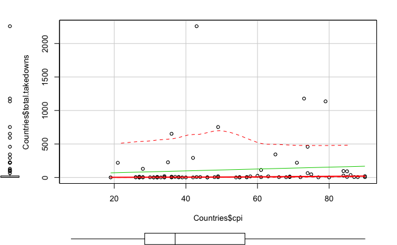

```r
### Correlation: Linear relationships between metric variables
# Let's examine the relationship between corruption
# and takedown requests.
# Use a scatterplot to see how linear the relationship looks
scatterplot(Countries$cpi, Countries$total.takedowns)
```

```r
#check the correlation
cor.test(Countries$cpi, Countries$total.takedowns)
```

```
    Pearson's product-moment correlation

data:  Countries$cpi and Countries$total.takedowns
t = 0.7427, df = 74, p-value = 0.46
alternative hypothesis: true correlation is not equal to 0
95 percent confidence interval:
 -0.1421955  0.3055476
sample estimates:
       cor
0.08601762
```

```r
# the cor function allows us to construct a correlation matrix
cor(Countries[,c("gdp", "cpi", "total.takedowns")], use = "pairwise.complete.obs")
```

```
                       gdp        cpi total.takedowns
gdp             1.00000000 0.77518916      0.02167304
cpi             0.77518916 1.00000000      0.08601762
total.takedowns 0.02167304 0.08601762      1.00000000
```

```r
# the output is actually a matrix object, so we can
# do things like square each value to get R-squared
cor(Countries[,c("gdp", "cpi", "total.takedowns")], use = "pairwise.complete.obs")**2
```

```
                         gdp         cpi total.takedowns
gdp             1.0000000000 0.600918228    0.0004697205
cpi             0.6009182276 1.000000000    0.0073990311
total.takedowns 0.0004697205 0.007399031    1.0000000000
```

#### Chi-square test

```r
### Chi-square: Testing for relationships between categorical variables
# Here are three different approaches, depending on structure of dataset
## 1. Two categorical variables
# Look at the frequency table between region and whether a country is corrupt
table(Countries$region, Countries$high_cpi)
```

```
           Corrupt Trustworthy
  Africa        35           7
  Americas      17           7
  Asia          19           8
  Europe         9          26
  Oceania        2           4
```

```r
# We store the results of our chi-square test so we can extract more
# values from the output
cs = chisq.test(Countries$region, Countries$high_cpi)
```

```
Chi-squared approximation may be incorrect
```

```r
# Examine the test result
cs
```

```
    Pearson's Chi-squared test

data:  Countries$region and Countries$high_cpi
X-squared = 31.08, df = 4, p-value = 2.948e-06
```

```r
# Look at the std. residuals to see which regions contribute most to the result
cs$stdres
```

```
                Countries$high_cpi
Countries$region   Corrupt Trustworthy
        Africa    3.553393   -3.553393
        Americas  1.069556   -1.069556
        Asia      1.094985   -1.094985
        Europe   -5.011243    5.011243
        Oceania  -1.432885    1.432885
```

```r
# Check the expected counts to see if any are less than 5 and
# if we should therefore try Fisher's exact test
cs$expected
```

```
                Countries$high_cpi
Countries$region   Corrupt Trustworthy
        Africa   25.701493   16.298507
        Americas 14.686567    9.313433
        Asia     16.522388   10.477612
        Europe   21.417910   13.582090
        Oceania   3.671642    2.328358
```

```r
# Use Fisher's exact test in this case:
fisher.test(Countries$region, Countries$high_cpi)
```

```
    Fisher's Exact Test for Count Data

data:  Countries$region and Countries$high_cpi
p-value = 1.563e-06
alternative hypothesis: two.sided
```

```r
# For an effect size, we could compute Cramer's V manually
# We may wish to put the code in a function so we can use
# it again whenever we want.
cramers_v = function(cs)
{
    cv = sqrt(cs$statistic / (sum(cs$observed) * (min(dim(cs$observed))-1)))
    print.noquote("Cramer's V:")
    return(as.numeric(cv))
}
# run our new function on our chi-square test
cramers_v(cs)
```

```
[1] Cramer's V:
[1] 0.4816019
```

```r
# As a rule of thumb,
# Cramer's V under .2 is weak
# between .2 and .4 is strong
# and above .4 is very strong
## 2. Count data, one variable in columns
# Consider each request to be the unit of analysis, and consider two variables:
# Whether it came from a corrupt or trustworthy country; and whether it came
# through a court order or executive/police action.  We want to know if these
# variables are independent or related.
# We can use aggregate to collapse the rows to just the high_cpi variable
Corrupt_Source = aggregate(Countries[,c("Court.Orders", "Executive..Police..etc.")], list(high_cpi = Countries$high_cpi), sum, na.rm=T)
# Note that we've created a table of counts:
Corrupt_Source
```

| high_cpi | Court.Orders | Executive..Police..etc. |
| --- | --- | --- |
| Corrupt | 2032 | 1863 |
| Trustworthy | 2328 | 2432 |

```r
# Not required, but we can add row names to make the chi-square output prettier
rownames(Corrupt_Source)=Corrupt_Source$high_cpi
# We want to plug our count table into the chi-square test
# but we first have to remove the first column,
# because it's a factor.
# Otherwise, R will throw an error.
# Notice that we can use a negative index to omit columns
# That is, we can choose columns 2 and 3 with c(2,3)
# or we can get the same thing by skipping column 1 with c(-1)
Corrupt_Source[,c(-1)]
```

|  | Court.Orders | Executive..Police..etc. |
| --- | --- | --- |
| Corrupt | 2032 | 1863 |
| Trustworthy | 2328 | 2432 |

```r
# Plug this into the Chi-square test
cs = chisq.test(Corrupt_Source[,c(-1)])
cs
```

```
    Pearson's Chi-squared test with Yates' continuity correction

data:  Corrupt_Source[, c(-1)]
X-squared = 8.9873, df = 1, p-value = 0.002719
```

```r
# Look at the standardized residuals to see which direction the effect is in
cs$stdres
```

```
            Court.Orders Executive..Police..etc.
Corrupt         3.019497               -3.019497
Trustworthy    -3.019497                3.019497
```

```r
# Check the expected counts to see if any are less than 5 and
# if we should therefore try Fisher's exact test
cs$expected
```

```
            Court.Orders Executive..Police..etc.
Corrupt         1962.126                1932.874
Trustworthy     2397.874                2362.126
```

```r
# Since we have a 2x2 matrix, we can measure the effect
# size elegantly as an odds ratio.
# First, get the odds an order came from a Court for
# corrupt countries
corrupt_odds = Corrupt_Source["Corrupt","Court.Orders"] / Corrupt_Source["Corrupt","Executive..Police..etc."]
# Do the same for the trustworth countries.
trustworthy_odds = Corrupt_Source["Trustworthy","Court.Orders"] / Corrupt_Source["Trustworthy","Executive..Police..etc."]
# The odds ratio is just one divided by the other
corrupt_odds / trustworthy_odds
```

```
[1] 1.13944
```

```r
## 3. Count data, both variables in rows
# Let's see if corrupt countries are likely to target different products
# than trustworthy ones.  For this, we can't aggregate our data by Country
# so go back to the original request data, and merge in the high_cpi variable
# also, remove countries that are missing corruption data
Requests2 = merge(Countries[,c("Country", "high_cpi")], Requests, by="Country")
Requests2 = Requests2[ ! is.na(Requests2$high_cpi),]
head(Requests2)
```

|  | Country | high_cpi | Period.Ending | CLDR.Territory.Code | Product | Reason | Court.Orders | Executive..Police..etc. | Items.Requested.To.Be.Removed | total.takedowns |
| --- | --- | --- | --- | --- | --- | --- | --- | --- | --- | --- |
| 1 | Argentina | Corrupt | 6/30/11 | AR | Web Search | Other | 1 | 0 | 1 | 1 |
| 2 | Argentina | Corrupt | 6/30/11 | AR | Web Search | Privacy and Security | 8 | 0 | 14 | 8 |
| 3 | Argentina | Corrupt | 6/30/11 | AR | Google AdWords | Defamation | 0 | 1 | 4 | 1 |
| 4 | Argentina | Corrupt | 6/30/11 | AR | Web Search | Defamation | 6 | 0 | 34 | 6 |
| 5 | Argentina | Corrupt | 6/30/11 | AR | Blogger | Defamation | 4 | 0 | 5 | 4 |
| 6 | Argentina | Corrupt | 6/30/11 | AR | Blogger | Privacy and Security | 1 | 0 | 1 | 1 |

```r
# We want separate columns for takedown requests from corrupt countries
# and from trustworthy countries.  Here, we create both columns, and copy
# each value for total.takedowns to the appropriate one.
Corrupt_Product = Requests2[,c("Product","high_cpi")]
Corrupt_Product$Corrupt = ifelse(Requests2$high_cpi == "Corrupt", Requests2$total.takedowns, 0)
Corrupt_Product$Trustworthy = ifelse(Requests2$high_cpi == "Trustworthy", Requests2$total.takedowns, 0)
# Observe that each row only has a positive value in one of the two new columns
head(Corrupt_Product)
```

|  | Product | high_cpi | Corrupt | Trustworthy |
| --- | --- | --- | --- | --- |
| 1 | Web Search | Corrupt | 1 | 0 |
| 2 | Web Search | Corrupt | 8 | 0 |
| 3 | Google AdWords | Corrupt | 1 | 0 |
| 4 | Web Search | Corrupt | 6 | 0 |
| 5 | Blogger | Corrupt | 4 | 0 |
| 6 | Blogger | Corrupt | 1 | 0 |

```r
# Next we sum Corrupt and Trustworthy columns for each product.
Corrupt_Product =  aggregate(Corrupt_Product[,c("Corrupt","Trustworthy")], list( Product = Corrupt_Product$Product), sum)
# We are left with a contingency table
Corrupt_Product
```

| Product | Corrupt | Trustworthy |
| --- | --- | --- |
| __\x84\xe2___\xb5\x84\xe2\x84\xdc | 26 | 0 |
| Blogger | 600 | 743 |
| Gmail | 22 | 80 |
| Google AdSense | 2 | 1 |
| Google AdWords | 3 | 131 |
| Google App Engine | 1 | 0 |
| Google Apps | 0 | 4 |
| Google Books | 3 | 6 |
| Google Code | 2 | 0 |
| Google Docs | 2 | 11 |

[output cut: 25 more lines]

```r
# We could have also created the table in one step, using the cast command
library(reshape)
Corrupt_Product = cast(Requests2, Product ~ high_cpi , fun = sum, value = c("total.takedowns"))
Corrupt_Product
```

|  | Product | Corrupt | Trustworthy |
| --- | --- | --- | --- |
| 1 | __\x84\xe2___\xb5\x84\xe2\x84\xdc | 26 | 0 |
| 2 | Blogger | 600 | 743 |
| 3 | Gmail | 22 | 80 |
| 4 | Google AdSense | 2 | 1 |
| 5 | Google AdWords | 3 | 131 |
| 6 | Google App Engine | 1 | 0 |
| 7 | Google Apps | 0 | 4 |
| 8 | Google Books | 3 | 6 |
| 9 | Google Code | 2 | 0 |
| 10 | Google Docs | 2 | 11 |

[output cut: 25 more lines]

```r
# Run a chi-square test as before
cs = chisq.test(Corrupt_Product[,c(-1)])
```

```
Chi-squared approximation may be incorrect
```

```r
cs
```

```
    Pearson's Chi-squared test

data:  Corrupt_Product[, c(-1)]
X-squared = 2292.2, df = 34, p-value < 2.2e-16
```

```r
# Check standardized residuals
cs$stdres
```

```
              [,1]         [,2]
 [1,]   5.64533503  -5.64533503
 [2,]  -0.26189811   0.26189811
 [3,]  -4.78559029   4.78559029
 [4,]   0.75436229  -0.75436229
 [5,] -10.02835447  10.02835447
 [6,]   1.10554096  -1.10554096
 [7,]  -1.80959184   1.80959184
 [8,]  -0.70406271   0.70406271
 [9,]   1.56356135  -1.56356135
[10,]  -2.14816521   2.14816521
[11,]   1.10554096  -1.10554096
[12,]  -1.99562733   1.99562733
[13,]  -5.28641745   5.28641745
[14,]  -1.71330740   1.71330740
```

[output cut: 21 more lines]

```r
# And expected values
cs$expected
```

```
              [,1]         [,2]
 [1,]   11.7007510   14.2992490
 [2,]  604.3887926  738.6112074
 [3,]   45.9029463   56.0970537
 [4,]    1.3500867    1.6499133
 [5,]   60.3038706   73.6961294
 [6,]    0.4500289    0.5499711
 [7,]    1.8001155    2.1998845
 [8,]    4.0502600    4.9497400
 [9,]    0.9000578    1.0999422
[10,]    5.8503755    7.1496245
[11,]    0.4500289    0.5499711
[12,]   12.1507799   14.8492201
[13,]   30.6019642   37.3980358
[14,]   31.0519931   37.9480069
```

[output cut: 21 more lines]

```r
# The fisher test is probably too computationally intensive to run
#fisher.test(Corrupt_Product[,c(-1)])
# could also use monte-carlo simulation to check significance
chisq.test(Corrupt_Product[,c(-1)], simulate.p.value = T)
```

```
    Pearson's Chi-squared test with simulated p-value (based on 2000 replicates)

data:  Corrupt_Product[, c(-1)]
X-squared = 2292.2, df = NA, p-value = 0.0004998
```

```r
# let's use the function we wrote earlier to check the effect size
cramers_v(cs)
```

```
[1] Cramer's V:
[1] 0.5146303
```

## T-test

#### T-test types

- Independent
- Dependent
- Parametric/non-parametric
- if underline distribution is normally distributed => parametric
- if not non-parametric, can use rank
  - wilcox.test()

### dependent (pared) t test

- t.test()
- If dataframe has single column: use t.test(outcome ~ predictor, data, paired = F/T)
- If dataframe has 2 columns: use t.test(score group 1, score group 2, paired = F/T)

#### R functions for t-distribution

- dt : Density of t-distributon
- pt : Distribution prob of t-distribution
- qt : quantile
- rt : generate random variable

## T-tests example 1

```r
# Use the Countries dataset, including takedown variables
load("./data/Countries3.Rdata")
summary(Countries)
```

```
   Country          infant.mortality      gdp        fertility_rate  contraception
 Length:194         Min.   :  3.00   Min.   :   36   Min.   :1.190   Min.   : 2.00
 Class :character   1st Qu.: 13.00   1st Qu.:  435   1st Qu.:1.855   1st Qu.:19.75
 Mode  :character   Median : 35.00   Median : 1570   Median :3.070   Median :46.00
                    Mean   : 46.48   Mean   : 6195   Mean   :3.542   Mean   :41.49
                    3rd Qu.: 72.50   3rd Qu.: 6232   3rd Qu.:5.025   3rd Qu.:61.25
                    Max.   :154.00   Max.   :42416   Max.   :7.600   Max.   :83.00
                    NA's   :51       NA's   :49      NA's   :51      NA's   :82
      region    Country_Code internet_users_2010 internet_users_2011 Corruption_Rank
 Africa  :42   AFG    :  1   Min.   : 0.25       Min.   : 0.98       Min.   :  1.00
 Americas:26   AGO    :  1   1st Qu.:10.00       1st Qu.:11.67       1st Qu.: 44.50
 Asia    :28   ALB    :  1   Median :27.67       Median :32.00       Median : 88.00
 Europe  :38   AND    :  1   Mean   :33.61       Mean   :37.50       Mean   : 87.17
 Oceania :14   ARG    :  1   3rd Qu.:53.00       3rd Qu.:59.50       3rd Qu.:130.75
 NA's    :46   (Other):143   Max.   :95.00       Max.   :95.02       Max.   :174.00
               NA's   : 46   NA's   :49          NA's   :54          NA's   :18
      cpi        internet_growth      high_cpi         high_gdp   Court.Orders
 Min.   : 8.00   Min.   :-0.12500   Length:194         High:72   Min.   :   0.00
 1st Qu.:28.75   1st Qu.: 0.05765   Class :character   Low :73   1st Qu.:   0.00
 Median :37.00   Median : 0.11321   Mode  :character   NA's:49   Median :   1.00
 Mean   :43.27   Mean   : 0.21683                                Mean   :  53.34
 3rd Qu.:56.25   3rd Qu.: 0.24764                                3rd Qu.:   7.00
 Max.   :90.00   Max.   : 2.92000                                Max.   :1539.00
 NA's   :18      NA's   :55                                      NA's   :112
 Executive..Police..etc. total.takedowns
 Min.   :  0.00          Min.   :   1.00
 1st Qu.:  1.00          1st Qu.:   2.00
 Median :  4.00          Median :   5.00
 Mean   : 59.57          Mean   : 112.91
 3rd Qu.: 11.75          3rd Qu.:  23.75
 Max.   :719.00          Max.   :2258.00
 NA's   :112             NA's   :112
```

```r
# look at log gdp between the corrupt and
# trustworthy Country groups
Countries$loggdp = log10(Countries$gdp)
# The means look different between groups
by(Countries$loggdp, Countries$high_cpi, mean, na.rm = TRUE)
```

```
Countries$high_cpi: Corrupt
[1] 2.859729
-----------------------------------------------------------------
Countries$high_cpi: Trustworthy
[1] 3.821505
```

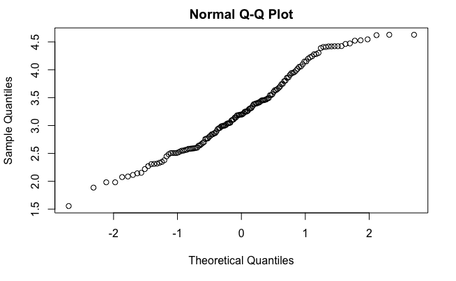

```r
# But is this statistically significant?
# From the qqplot, it's not clear if loggdp is normally distributed
qqnorm(Countries$loggdp)
```

```r
# The Shapiro test suggests that it's not
shapiro.test(Countries$loggdp)
```

```
    Shapiro-Wilk normality test

data:  Countries$loggdp
W = 0.97303, p-value = 0.005833
```

```r
# But we have a large sample size, so we can rely on
# the central limit theorem and use a regular t.test
t.test(Countries$loggdp ~ Countries$high_cpi, Countries)
```

```
    Welch Two Sample t-test

data:  Countries$loggdp by Countries$high_cpi
t = -9.2317, df = 96.768, p-value = 6.237e-15
alternative hypothesis: true difference in means is not equal to 0
95 percent confidence interval:
 -1.1685543 -0.7549991
sample estimates:
    mean in group Corrupt mean in group Trustworthy
                 2.859729                  3.821505
```

```r
## Computing effect sizes
# We can manually compute Cohen's d, a common measure of effect
# size for the difference between two means.
# Quite simply, Cohen's d is the difference between the means
# divided by their pooled standard error.
# We'll place our code in a function so we can use it again later
cohens_d <- function(x, y) {
    # this function takes two vectors as inputs, and compares
    # their means

    # first, compute the pooled standard error
  lx = length(subset(x,!is.na(x)))
  ly = length(subset(y,!is.na(y)))
    # numerator of the pooled variance:
    num = (lx-1)*var(x, na.rm=T) + (ly-1)*var(y, na.rm=T)
    pooled_var = num / (lx + ly - 2) # variance
    pooled_sd = sqrt(pooled_var)

    # finally, compute cohen's d
    cd = abs(mean(x, na.rm=T) - mean(y, na.rm=T)) / pooled_sd
    return(cd)
}
# get the vectors of loggdp for each of our two groups
loggdp_c = Countries$loggdp[Countries$high_cpi=="Corrupt"]
loggdp_t = Countries$loggdp[Countries$high_cpi=="Trustworthy"]
# plug them into our cohen's d function
cohens_d(loggdp_c, loggdp_t)
```

```
[1] 1.692301
```

```r
# We could also compute the effect size correlation
# this is, quite simply, the correlation between the our metric
# variable and our grouping variable (suitably dummy-coded)
cor.test(Countries$loggdp, as.numeric(factor(Countries$high_cpi)))
```

```
    Pearson's product-moment correlation

data:  Countries$loggdp and as.numeric(factor(Countries$high_cpi))
t = 9.5463, df = 132, p-value < 2.2e-16
alternative hypothesis: true correlation is not equal to 0
95 percent confidence interval:
 0.5265574 0.7295925
sample estimates:
      cor
0.6390774
```

```r
## 2. Suppose we were just looking at countries in the Americas
Americas = Countries[Countries$region == "Americas",]
summary(Americas)
```

```
   Country          infant.mortality      gdp        fertility_rate  contraception
 Length:72          Min.   : 6.00    Min.   :  386   Min.   :1.550   Min.   :18.00
 Class :character   1st Qu.:14.00    1st Qu.: 1435   1st Qu.:2.303   1st Qu.:47.50
 Mode  :character   Median :24.00    Median : 2491   Median :2.660   Median :54.50
                    Mean   :30.56    Mean   : 3693   Mean   :2.935   Mean   :53.55
                    3rd Qu.:42.00    3rd Qu.: 4256   3rd Qu.:3.708   3rd Qu.:63.50
                    Max.   :82.00    Max.   :18943   Max.   :4.900   Max.   :74.00
                    NA's   :47       NA's   :46      NA's   :48      NA's   :50
      region    Country_Code internet_users_2010 internet_users_2011 Corruption_Rank
 Africa  : 0   ARG    : 1    Min.   : 8.37       Min.   :10.60       Min.   :  9.00
 Americas:26   BHS    : 1    1st Qu.:20.45       1st Qu.:30.70       1st Qu.: 53.75
 Asia    : 0   BLZ    : 1    Median :32.52       Median :36.50       Median : 91.00
 Europe  : 0   BOL    : 1    Mean   :32.94       Mean   :39.45       Mean   : 87.67
 Oceania : 0   BRA    : 1    3rd Qu.:40.51       3rd Qu.:49.51       3rd Qu.:121.00
 NA's    :46   (Other):21    Max.   :80.30       Max.   :83.00       Max.   :165.00
               NA's   :46    NA's   :46          NA's   :49          NA's   :48
      cpi        internet_growth     high_cpi         high_gdp   Court.Orders
 Min.   :19.00   Min.   :0.01298   Length:72          High:18   Min.   :   0.0
 1st Qu.:31.25   1st Qu.:0.06754   Class :character   Low : 8   1st Qu.:   1.0
 Median :36.50   Median :0.10701   Mode  :character   NA's:46   Median :   2.5
 Mean   :42.79   Mean   :0.15814                                Mean   : 179.7
 3rd Qu.:50.50   3rd Qu.:0.19512                                3rd Qu.:  31.0
 Max.   :84.00   Max.   :0.51163                                Max.   :1539.0
 NA's   :48      NA's   :49                                     NA's   :62
 Executive..Police..etc. total.takedowns      loggdp
 Min.   :  0.00          Min.   :   1.0   Min.   :2.587
 1st Qu.:  1.25          1st Qu.:   2.5   1st Qu.:3.156
 Median :  6.00          Median :   7.5   Median :3.396
 Mean   : 82.70          Mean   : 262.4   Mean   :3.374
 3rd Qu.: 19.75          3rd Qu.:  77.0   3rd Qu.:3.627
 Max.   :719.00          Max.   :2258.0   Max.   :4.277
 NA's   :62              NA's   :62       NA's   :46
```

```r
# We may ask whether the more corrupt countries in this
# group issue more or less takedown requests than the
# more trustworthy ones
by(Americas$total.takedowns, Americas$high_cpi, mean, na.rm = TRUE)
```

```
Americas$high_cpi: Corrupt
[1] 315.5
-----------------------------------------------------------------
Americas$high_cpi: Trustworthy
[1] 50
```

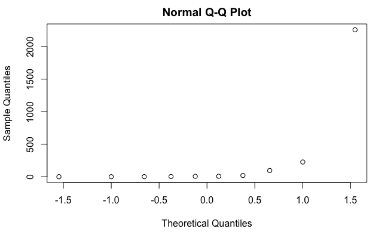

```r
# Notice that total takedowns is not at all normal.
qqnorm(Americas$total.takedowns)
```

```r
# Use the Wilcoxon rank-sum test to compare means
wilcox.test(Americas$total.takedowns ~ Americas$high_cpi)
```

```
cannot compute exact p-value with ties
```

```
    Wilcoxon rank sum test with continuity correction

data:  Americas$total.takedowns by Americas$high_cpi
W = 7, p-value = 0.8958
alternative hypothesis: true location shift is not equal to 0
```

```r
# we can compute cohen's d using the function we wrote earlier
takedowns_c = Americas$total.takedowns[Americas$high_cpi == "Corrupt"]
takedowns_t = Americas$total.takedowns[Americas$high_cpi == "Trustworthy"]
cohens_d(takedowns_c, takedowns_t)
```

```
[1] 0.3596996
```

```r
## Let's finally compare the number of takedown requests
# issued by courts, with those issued by executives / police
mean(Countries$Court.Orders, na.rm = T)
```

```
[1] 53.34146
```

```r
mean(Countries$Executive, na.rm = T)
```

```
[1] 59.57317
```

```r
# Because there is just one group of countries, with two
# variables per country, we need a paired-samples test
# (paired = TRUE)
#
# In general, we need a paired-sample t-test whenever
# we can pair each observation in one sample with an
# observation in the other sample, and when we expect
# the observations in each pair to vary together to
# some extent.
#
# The pairing could be formed in several ways:
#
# 1. We have two variables for each unit of analysis
# The classic example here is giving a test twice to
# the same group of individuals (pretest-posttest).
# But we could also take two different measurements at
# the same time - such as court ordered takedowns and
# executive-ordered takedowns in our example.
#
# 2. We have a natural pairing between units of analysis
# This could be the case for measurements on twins, or
# spouses.
#
# 3. We create a matched sample by pairing units of
# analysis with similar characteristics
# Because of the large sample size, we can use the parametric
# t-test
t.test(Countries$Court.Orders, Countries$Executive, paired = T)
```

```
    Paired t-test

data:  Countries$Court.Orders and Countries$Executive
t = -0.36562, df = 81, p-value = 0.7156
alternative hypothesis: true difference in means is not equal to 0
95 percent confidence interval:
 -40.14479  27.68138
sample estimates:
mean of the differences
              -6.231707
```

```r
# effect size
cohens_d(Countries$Court.Orders, Countries$Executive)
```

```
[1] 0.03441315
```